# Hvem ligner du mest?

C-niveau

**Forudsætninger og tidsforbrug**

Forløbet kræver kendskab til:

- Afstand mellem to punkter.

**Tidsforbrug:** Ca. 2 x 90 minutter.

### Formål

Evnen til at skelne mellem forskellige kategorier er helt central for os som mennesker. Vi kan langt oftest kende forskel på et æble og en pære, på en cykel og en knallert eller på om en person er en kvinde eller en mand. Men hvordan får man en computer til at gøre det samme?

Formålet med dette forløb er at lære lidt om nogle af de metoder, som ligger bag, når en computer skal lære at kende forskel på forskellige ting.

## Introduktion

Vi har apps på vores telefoner eller computere, som ud fra et billede kan genkende personer eller fra nogle få strofer kan genkende en sang. Der er scannere i lufthavne og andre steder, som kan genkende farlige ting, og biler har autopiloter, der selv holder afstanden til forankørende. Vi har også apps, som går den anden vej, og forvrænger et billede af en person, så personen bliver svær at genkende, men ofte alligevel kan genkendes, selvom ansigtet er fordrejet.

Så alle steder og hele tiden foregår der bevist eller ubevist en skelnen mellem forskellige kategorier, men hvordan foregår denne skelnen i grunden? Hvis vi skulle svare fyldestgørende på dette spørgsmål, om overhovedet muligt, ville det nok betyde et langt studie på universitetet og sikkert mere end dette, men lad os starte med et meget simpelt eksempel, og tage den derfra.

Vi får brug for din viden om afstande mellem punkter, men kommer også til senere at se på andre former for afstande. Det er en fordel af lave opgaverne i grupper, da der kan blive en del af diskutere.

## VIDEO: Hvem ligner du mest?

I denne video gives en kort introduktion til forløbet.

[video not shown]

## Case 1 – Afstand mellem to punkter

**Opgave 1**

På figur 1 nedenfor er der $10$ røde punkter, $10$ blå punkter og $10$ grønne punkter – samt et enkelt gråt punkt $P$ i midten. Et af de blå punkter er særligt markeret, men da det ligger ret langt fra $P$ bør det nok ikke betyde så meget for, hvilket farve $P$ skal have, som de punkter, der ligger tættere på $P$

Vurdér ud fra de øvrige punkter i nærheden af $P$, om du synes, at $P$ bør være rødt, blåt eller grønt så det mest ligner sine naboer.

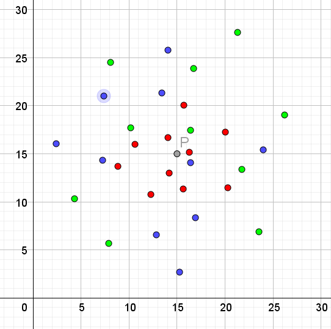

Figur 1: Koordinatsystem med $10$ røde punkter, $10$ blå punkter og $10$ grønne punkter – samt et enkelt gråt punkt $P$.

**Opgave 2**

På figur 2 er der andre $31$ punkter, samt en cirkel med radius $10$ omkring det grå punkt $P(15,15)$.

Tæl hvor mange røde, blå og grønne punkter, der ligger inde i cirklen. Kan det bruges til at beslutte, hvilken farve det grå punkt bør have?

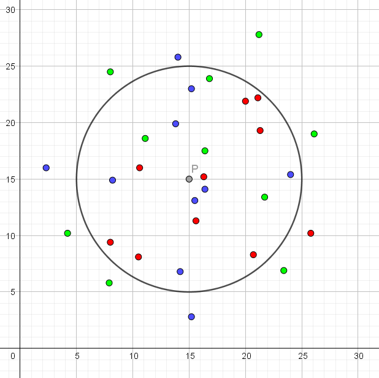

Figur 2: Koordinatsystem med $31$ punkter, samt en cirkel med radius $10$ omkring det grå punkt $P(15,15)$

**Opgave 2, fortsat**

**Opgave 3**

Det går nok ikke i længden blot at ville vurdere på øjemål, så du må til at regne lidt. I tabellen herunder er koordinater og farver på de $10$ punkter, der ligger tættest på det grå punkt i opgave 2.

Udregn afstanden fra det grå punkt $P(15,15)$ til hver af disse $10$ punkter.

Afgør så, hvor mange af hver farve, der ligger indenfor en cirkel med radius $5$ omkring det grå punkt. Det er nok specielt det blå punkt lige på kanten af cirklen, hvor beregningen er vigtig, men hvis en computer skal lave arbejdet automatisk, vil den jo beregne alle afstandene, da den ikke bare kan “kigge på figuren”, som et menneske kan.

Hvilken farve tyder det på, at det grå punkt bør have?

Tabellens data er punkter i kommatal. F.eks. er det første blå punkt $(13,8 ; 19,9)$, så det har x-koordinaten $13,8$ og y-koordinaten $19,9$.

| Farve | 1 | 2 | 3 | 4 |
| --- | --- | --- | --- | --- |
| Blå | $(13,8 ; 19,9)$ | $(8,2 ; 14,9)$ | $(16,4 ; 14,1)$ | $(15,5 ; 13,1)$ |
| Rød | $(10,6 ; 16,0)$ | $(16,3 ; 15,2)$ | $(15,6 ; 11,3)$ |  |
| Grøn | $(11,1 ; 18,6)$ | $(16,4 ; 17,5)$ | $(21,7 ; 13,4)$ |  |

**Opgave 4**

Overvej, hvad der sker, hvis cirklens radius vælges som en meget lille værdi eller som en meget stor værdi i forhold til at bruge metoden til at bestemme, hvilken farve det grå punkt bør have. Kan det give problemer?

**Opgave 5**

Diskutér, hvilken radius, der er bedst.

### Afslutning på case 1

Det bliver nok klart, at der er brug for en metode til at beslutte, hvor stor radius skal være for at få det bedste resultat. Kort og lidt simpelt forklaret, involverer det noget, som man kalder træningsdata og testdata. Man har f.eks. 1000 punkter, som man kender farven på. Man lader så som om, at man ikke kender farven på f.eks. 200 af punkterne (som man så kalder testdata). Så bruger man de øvrige 800 punkter (træningsdata) til at forudsige farven af hver af de 200 punkter i testdata. Dette gør man for forskellige værdier af radius, hvorefter man vælger den radius, der forudsiger flest af de 200 punkters farve korrekt. Hvis f.eks. radius 5 forudsiger 121 punkters farve korrekt, radius 10 furudsiger 135 punkters farve korrekt, og radius 20 kun forudsiger 87 punkters farve korrekt, så har radius 10 jo klaret sig bedst.

## Case 2 – Manhattan afstand

I nogle situationer giver den almindelige afstand mellem punkter ikke så god mening. F.eks. er de fleste veje på Manhattan i New York enten nord-syd eller øst-vest, så man kan ikke bare gå eller køre “på skrå”, men kun lodret eller vandret.

Hvis vi ser på punkterne $P(2,3)$ og $Q(5,7)$, så er den almindelige afstand $5$ vha. Pythagoras, mens Manhattan afstanden er $3+4=7$. Dette er illustreret på figur 3.

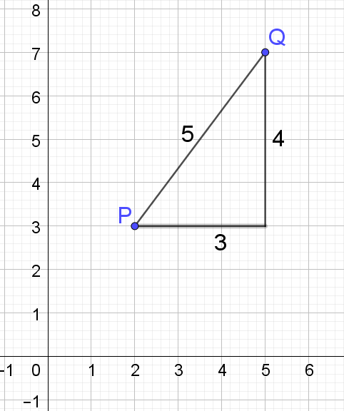

Figur 3: Den almindelige afstand mellem punkterne $P(2,3)$ og $Q(5,7)$ er $5$, mens Manhattan afstanden er $7$.

**Opgave 6**

Indtegn punkterne $A(1,7)$, $B(3,4)$ og $C(5,6)$ i et koordinatsystem.

Udregn både almindelig afstand og Manhattan afstand mellem hvert par af punkter.

**Opgave 7**

I eksemplet og i opgave 6 var Manhattan afstanden større end den almindelige afstand, men kan Manhattan afstanden være mindre end den almindelige afstand eller kan de to afstande være ens?

**Opgave 8**

Se på figur 4 fra opgave 2 igen.

Punkterne inde i cirklen har en almindelig afstand på under $10$ til det grå punkt, men hvilke af punkterne har en Manhattan afstand på under $10$ til det grå punkt?

Den almindelige afstand giver en cirkel med det grå punkt i centrum, men hvilken figur giver Manhatten afstand omkring det grå punkt?

Hvilken farve bør det grå punkt derfor have, hvis Manhattan afstanden benyttes? Giver det samme resultatet, som du fik i opgave 2?

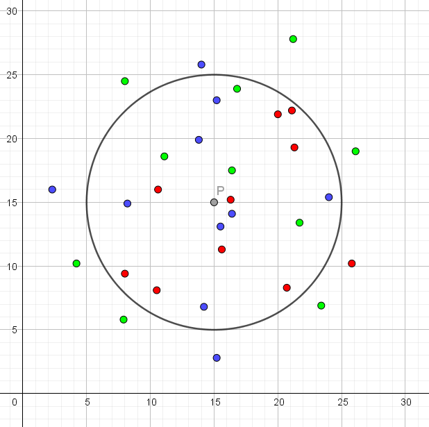

Figur 4: Koordinatsystem med $31$ punkter, samt en cirkel med radius $10$ omkring det grå punkt $P(15,15)$

**Opgave 9**

Opstil en formel for den almindelige afstand mellem to punkter med koordinaterne $(x_1, y_1)$ og $(x_2, y_2)$. Det er en formel, du kender i forvejen.

Opstil tilsvarende en formel for Manhattan afstanden. Det er nok ikke en formel, du har set før.

Du kan læse mere om Manhattan afstanden her.

## Case 3 – Hvor ens er to tekster?

I forbindelse med at undersøge om en tekst, f.eks. en dansk stil, er plagiat, bliver det relevant at sammenligne, hvor ens to tekster er. Helt så avanceret bliver det dog ikke her.

Vi vil kun se meget simpelt på ord med $5$ bogstaver, og hvordan man f.eks. kan måle afstande mellem forskellige ord. Vi vil se på alle kombinationer af $5$ bogstaver, også f.eks. xtmsp, selvom de ikke er normale ord.

**Opgave 10**

I tabellen herunder ses ordet “nedes” sammen med ordene “model”, “metal” og “nudts”.

|  | n | e | d | e | s |  |
| --- | --- | --- | --- | --- | --- | --- |
|  | m | o | d | e | l |  |
|  | m | e | t | a | l |  |
|  | n | u | d | t | s |  |

Hvilket af ordene “model”, “metal” og “nudts” synes du, at ordet “nedes” ligner mest. Begrund dit svar.

**Opgave 11**

Hvis vi vælger, at afstanden mellem to ord er antallet af bogstaver, som er forskellige incl. placering, så er afstanden mellem “xtmsp” og “xmtsq” $3$, da kun $2$ af de $5$ bogstaver matcher incl. placering i de to ord, nemlig x og s.

Udregn med den metode afstanden mellem “nedes” og hver af de $3$ ord i opgave 10. Var det sådan du allerede havde gjort det i opgave 10, eller gav dette et andet resultat?

**Opgave 12**

Overvej og diskuter andre måder at regne afstand mellem to ord på hver $5$ bogstaver. Det kunne f.eks. være noget, hvor ombytning af to nabobogstaver giver mindre afstand end helt tilfældige andre bogstaver, så f.eks. “kolon” og “kloon” er tættere på hinanden end “kolon” og “kston”.

## Case 4 – DNA-strenge og alignment

Uden i øvrigt at komme ind på biologien repræsenteres DNA som meget lange tekststrenge. Når mennesker og chimpanser er meget ens, kommer det til udtryk ved, at DNA-strengen for et menneske ligner den for en chimpanse meget, der er altså en kort afstand mellem DNA for et menneske og DNA for en chimpanse. Indenfor biologien kaldes dette for alignment. I stedet for at sammenligne på DNA niveau, sammenlignes også nogle gange på aminosyre niveau, hvilket vi vil bruge her,

Følgende eksempel, der viser et meget lille udsnit af sådanne koder fra mus, rotter, mennesker og gær er taget fra [Tema12-Link5.pdf (nucleus.dk)](https://www.nucleus.dk/files/docs/Bioteknologibogen.dk/Tema12-Link5.pdf), der kan anbefales, hvis man ønsker at arbejde mere med alignment.

| Dyr | Kode |
| --- | --- |
| Mus | S W A W A E G W T R Y G P |
| Rotte | K W V W A E G W T R Y G P |
| Menneske | A W A W A E G W T R Y G P |
| Gær | E W L R K P G W V K Y V P |

Hvis afstanden her regnes som antal bogstaver, der er forskellige, ses det at afstanden mellem mus og rotte er på $2$, som vist nedenfor.

| Dyr | Kode |
| --- | --- |
| Mus | **S** W **A** W A E G W T R Y G P |
| Rotte | **K** W **V** W A E G W T R Y G P |

**Opgave 13**

Udregn på tilsvarende vis afstandene mellem mus-menneske, mus-gær, rotte-menneske, rotte-gær og menneske-gær.

Når resultatet sikkert virker overraskende, skyldes det, at vi kun har set på et meget lille udsnit af DNA for de fire. I figur 5 har man set på hele det protein, som udsnittet stammer fra, og her bliver resultatet mere som forventet.

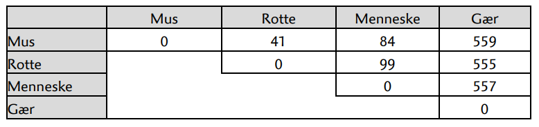

Figur 5: De faktiske afstande mellem mus-menneske, mus-gær, rotte-menneske, rotte-gær og menneske-gær.

## Case 5 – Hvilken politiker er du mest enig med?

Op til både folketingsvalg og kommunal- og regionalvalg kan man svare på en række spørgsmål, hvorefter ens svar bliver sammenlignet med politikernes svar på de samme spørgsmål. Herefter kan man så se, hvem man er mest enig med.

Her er et eksempel fra kommunal- og regionalvalget i 2021.

[Tag kandidattesten Kommunalvalg 2021 - Altinget - Alt om politik: altinget.dk](https://www.altinget.dk/valg/KV21/kandidattest)

**Opgave 14**

Klik på linket ovenfor, vælg din egen kommune i testen og besvar spørgsmålene. Se derefter, hvem dine svar er mest enige med, og hvor mange procent enige I er.

Men hvordan virker det mon? Hvordan vurderes, hvilken kandidat du er mest enig med, og hvordan udregnes, hvor mange procent enige I er?

Til hvert spørgsmål kan der svares “helt uenig”, “uenig”, “enig” eller “helt enig”, men desuden er der en skjult “neutral” mulighed i midten, som man ikke kan vælge.

| Helt uenig | Uenig | Neutral | Enig | Helt enig |
| --- | --- | --- | --- | --- |

Afstanden mellem to svar regnes som antal “felter” i tabellen, så afstanden mellem Uenig og Enig er $2$, mens afstanden mellem Enig og Helt enig er $1$, og den største afstand er $4$.

I figur 6 ses en persons svar og et partis svar på $23$ spørgsmål til kommunalvalget i 2021. Ved et partis svar forstås det svar, som flest af kandidaterne fra partiet har givet (ved lighed afgjort ud af, hvilken kandidat, der står først på listen). Så det er typetallet (typesvaret), der er anvendt for partierne, ikke gennemsnittet af svarene fra partiets kandidater. Figuren er fra testen på Altinget. Bemærk, at antallet af spørgsmål kan variere fra kommune til kommune, så du har måske færre eller flere spørgsmål.

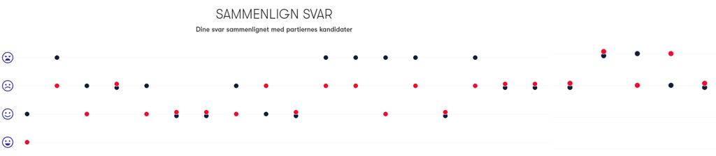

Figur 6: En persons svar (sort) og et partis svar (rød) på $23$ spørgsmål til kommunalvalget i 2021.

Afstanden i det første spørgsmål er $1$, afstanden i det andet spørgsmål også $1$ og afstanden i det tredje spørgsmål er $2$ pga. den skjulte “neutral” mulighed i midten.

**Opgave 15**

De 3 første afstand er altså 1, 1 og 2. Udregn afstanden for hver af de øvrige $20$ spørgsmål.

Læg så afstandene sammen, hvilket svarer til en form for Manhattan afstand, da afstanden regnes for hvert enkelt spørgsmål for sig. Hvilken samlet afstand giver det?

**Opgave 16**

Hvad er den mindst mulig samlede afstand for de $23$ spørgsmål? Hvordan skal svarene for partiet og for vælgeren se ud fra at få denne afstand?

Hvad er den størst mulige afstand, og hvordan skal svarene så se ud?

**Opgave 17**

På figur 7 ses det, at siden angiver, at enigheden med Socialdemokratiet er på $79 \%$.

Overvej, hvordan den afstand du udregnede i opgave 15 og den største mulige afstand, som du fandt i opgave 16, kan betyde, at enigheden er $79 \%$.

[figure not shown]

Figur 7: På siden angives det, at enigheden med Socialdemokratiet er på $79 \%$.

**Opgave 18**

Vend tilbage til dine egne svar på testen.

Beregn afstand og procent i forhold til den kandidat, du var mest enig med, og den kandidat, du var mest uenig med.

Beregn desuden afstand og procent til det parti, du var mest enig med, og til det parti, du var mest uenig med.

Passer dine udregninger med sidens procenter?

**Opgave 19 (svær)**

Den kandidat, som svarene i opgave 15 var mest enig med, giver en procent på $76 \%$, så procenten for samtlige kandidater fra Socialdemokratiet er altså lavere end procenten for selve partiet.

Det virker måske umiddelbart underligt. Overvej, hvorfor det faktisk er korrekt ud fra den metode, som siden anvender til beregningerne.

Diskutér derefter, om procenten for partiet kunne være beregnet anderledes.